# 13vaSemanaProgramacion120321

## Programación - Ciencia de datos - Algoritmos, pseudocódigo, diagrama de flujo

Fecha: 12/03/21

## Algoritmos. Definición

**"Un algoritmo se puede definir como una secuencia de instrucciones que representan un modelo de solución para determinado tipo de problemas."**

**"Un conjunto de instrucciones que realizadas en orden conducen a obtener la solución de un problema."**

Para realizar un programa es conveniente el diseño o definición previa del algoritmo.

“en la ciencia de la computación y en la programación, los algoritmos son más importantes que los lenguajes de programación o las computadoras. Un lenguaje de programación es sólo un medio para expresar un algoritmo y una computadora es sólo un procesador para ejecutarlo”.

Los algoritmos son independientes de los lenguajes de programación. En cada problema el algoritmo puede escribirse y luego ejecutarse en un lenguaje diferente de programación. El algoritmo es la infraestructura de cualquier solución, escrita luego en cualquier lenguaje de programación.

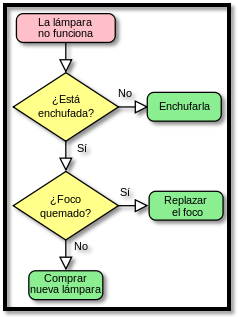

### Características de los algoritmos

**•Preciso.** Definirse de manera rigurosa, sin dar lugar a ambigüedades.

**•Definido.** Si se sigue un algoritmo dos veces, se obtendrá el mismo resultado.

**•Finito.** Debe terminar en algún momento.

**•Puede tener cero o más elementos de entrada.**

**•Debe producir un resultado.** Los datos de salida serán los resultados de efectuar las instrucciones.Se concluye que un algoritmo debe ser suficiente para resolver el problema.

Entre dos algoritmos que lleven a un mismo objetivo, siempre será preferible el más corto (se deberá analizar la optimización de tiempos y / o recursos).

### Etapas para la solución de un problema por medio del computador

1.Análisis del problema, definición y delimitación (macroalgoritmo). Considerar los datos de entrada, el proceso que debe realizar el computador y los datos de salida.

2.Diseño y desarrollo del algoritmo (se utiliza pseudocódigo, escritura natural del algoritmo, diagramas de flujo, etc.)

3.Prueba de escritorio. Seguimiento manual de los pasos descritos en el algoritmo. Se hace con valores bajos y tiene como fin detectar errores.

4.Codificación. Selección de un lenguaje de programación y digitación del pseudocódigo haciendo uso de la sintaxis y estructura gramatical del lenguaje seleccionado.

5.Compilación o interpretación del programa. El software elegido convierte las instrucciones escritas en el lenguaje a las comprendidas por el computador.

6.Ejecución. El programa es ejecutado por la máquina para llegar a los resultados esperados.

7.Depuración (debug). Operación de detectar, localizar y eliminar errores de mal funcionamiento del programa.

8.Evaluación de resultados. Obtenidos los resultados se los evalúa para verificar si son correctos. (Un programa puede arrojar resultados incorrectos aún cuando su ejecución no muestra erorres).

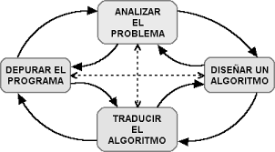

### Técnicas de representación

Para la representación de un algoritmo, antes de ser convertido a lenguaje de programación, se utilizan algunos métodos de representación escrita, gráfica o matemática. Los métodos más conocidos son:

**•Pseudocódigo**

**•Diagramación libre (Diagramas de flujo)**

**•Diagramas Nassi-Shneiderman**

**•Lenguaje natural (español, inglés, etc.)**

**•Fórmulas matemáticas**

El lenguaje natural puede no ser suficientemente preciso, permitiendo ambigüedades, obteniendo una descripción no del todo satisfactoria. Las fórmulas, propias del lenguaje matemático, son un buen sistema de representación, pero no suelen ser fáciles de convertir en programas.

## Diagrama de flujo

### Visustin

https://www.aivosto.com/visustin-es.html

### genmymodel

https://www.genmymodel.com/pricing/

## Simbolos de diagramas de flujo

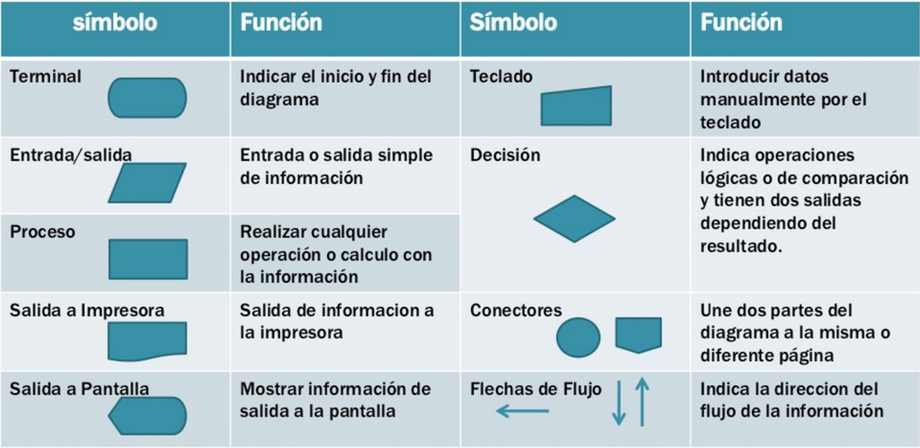

## Ejemplo de diagrama de flujo

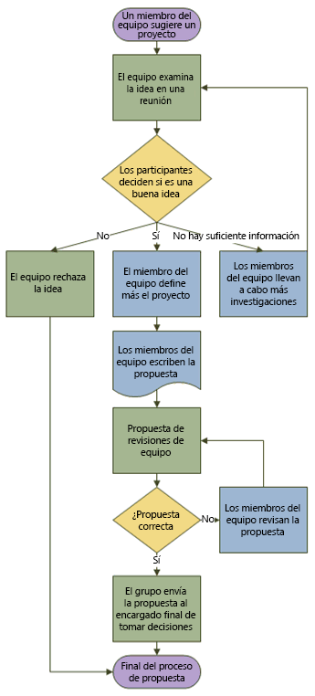

## Ejemplos en pseudocódigo

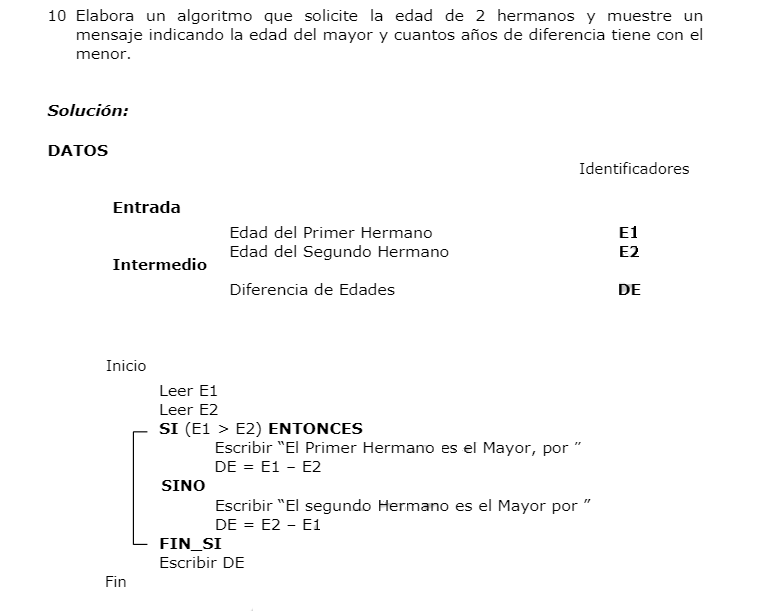

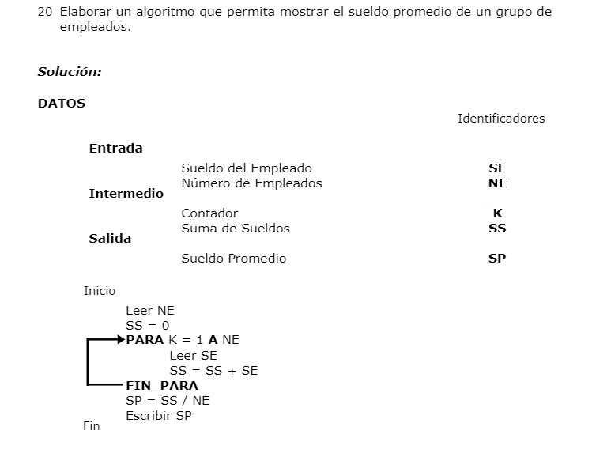

## Depuración: Ver paso a paso un programa en python

https://runestone.academy/runestone/books/published/StudentCSP/CSPNameNumbers/driving.html

https://runestone.academy/runestone/static/instructorguide/Directives/codelensPython.html#:~:text=The%20codelens%20feature%20allows%20the,the%20Student%20Computer%20Science%20Principles.

## Ejercicio 2

Escriba un programa que permita crear una lista de palabras (que puede ser vacía).

Para ello, el programa tiene que pedir un número y luego solicitar ese número de palabras para crear la lista.

Por último, el programa tiene que mostrar la lista.

## Ejercicio 3

Escribir un programa que pida al usuario una palabra y muestre por pantalla el número de veces que contiene cada vocal.

## Ejercicio 4

Escriba un programa que permita crear dos listas de palabras y que, a continuación, elimine de la primera lista los nombres que se repiten en la segunda lista.

## Ejercicio 6

Solicitar al usuario que ingrese su dirección email. Imprimir un mensaje indicando si la dirección es válida o no, valiéndose de una función para decidirlo. Una dirección se considerará válida si contiene el símbolo "@", y el .com.

## Ejercicio 7

Sin ejecutar el siguiente programa, determinar cuál es la salida en pantalla si se ingresan los valores x=6, y=7:

def coordenadaZ(x,y):

x=x+10

y=y+15

return x+y

# programa principal

x=int(input("Coordenada eje x: "))

y=int(input("Coordenada eje y: "))

for i in range(3):

z=coordenadaZ(x,y)

x=x+1

y=y+1

print(x," . ",y)

## Ejercicio 8

Escribir un programa que almacene las asignaturas de un curso (por ejemplo Matemáticas, Física, Química, Historia y Lengua) en una lista y la muestre por pantalla.

## Ejercicio 9

Escribir un programa que almacene las asignaturas de un curso (por ejemplo Matemáticas, Física, Química, Historia y Lengua) en una estructura de datos, pregunte al usuario la nota que ha sacado en cada asignatura y elimine de la estructura de datos las asignaturas aprobadas. Al final el programa debe mostrar por pantalla las asignaturas que el usuario tiene que repetir.

## Ejercicio 10

Escribir un programa que almacene en una lista los números del 1 al 10 y los muestre por pantalla en orden inverso separados por comas.

## Algoritmos en machine learning

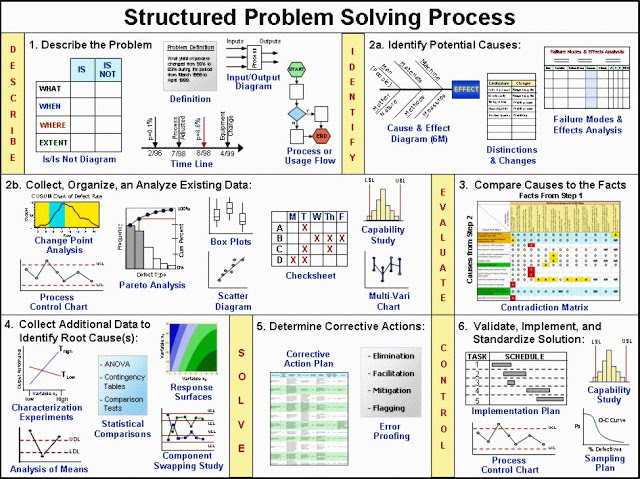

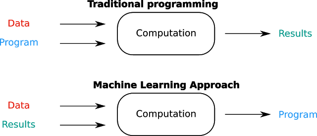

fuente: https://todobi.com/que-algoritmo-de-machine-learning/